# Simulation Tools Provided With the Selectboost Package

Frédéric Bertrand and Myriam Maumy-Bertrand

Université de Strasbourg and CNRSIRMA, labex IRMIA  
frederic.bertrand@utt.fr

2022-11-29

# Contents

This vignette details the simulations tools provided with the selectboost package by providing five examples of use.

If you are a Linux/Unix or a Macos user, you can install a version of SelectBoost with support for `doMC` from [github](https://github.com) with:

```r
devtools::install_github("fbertran/SelectBoost", ref = "doMC")
```

# First example

## Aim

We want to creates $NDatasets=200$ datasets with $\textrm{length}(group)=10$ variables and $N=10$ observations. In that example we want $9$ groups:

- $x_1$ and $x_{10}$ belong to the first group and the intra-group Pearson correlation for this group is equal to $.95$,
- $x_2$ belongs to the second group,
- $x_3$ belongs to the third group,
- …
- $x_9$ belongs to the ninth group.

## Correlation structure

The correlation structure of the explanatory variables of the dataset is provided by `group` and the intra-group Pearson correlation value for each of the groups by `cor_group`. A value must be provided even for single variable groups and the number of variables is length of the `group` vector. Use the `simulation_cor` function to create the correlation matrix (`CM`).

```r
library(SelectBoost)
group<-c(1:9,1) #10 variables
cor_group<-rep(0.95,9)
CM<-simulation_cor(group,cor_group)
CM
```

```
#>       [,1] [,2] [,3] [,4] [,5] [,6] [,7] [,8] [,9] [,10]
#>  [1,] 1.00    0    0    0    0    0    0    0    0  0.95
#>  [2,] 0.00    1    0    0    0    0    0    0    0  0.00
#>  [3,] 0.00    0    1    0    0    0    0    0    0  0.00
#>  [4,] 0.00    0    0    1    0    0    0    0    0  0.00
#>  [5,] 0.00    0    0    0    1    0    0    0    0  0.00
#>  [6,] 0.00    0    0    0    0    1    0    0    0  0.00
#>  [7,] 0.00    0    0    0    0    0    1    0    0  0.00
#>  [8,] 0.00    0    0    0    0    0    0    1    0  0.00
#>  [9,] 0.00    0    0    0    0    0    0    0    1  0.00
#> [10,] 0.95    0    0    0    0    0    0    0    0  1.00
```

## Explanatory dataset generation

Then generation of an explanatory dataset with $N=10$ observations is made by the `simulation_X` function.

```r
set.seed(3141)
N<-10
X<-simulation_X(N,CM)
X
```

```
#>              [,1]       [,2]        [,3]       [,4]        [,5]        [,6]
#>  [1,]  0.69029599 -1.7343187  0.38993973  0.7530345  0.73462394  1.91645527
#>  [2,] -0.55429733  1.5236359 -0.44435298 -0.8293970  0.02137105  1.62014297
#>  [3,] -0.65277340 -0.2365804 -0.33365748  1.6144115 -1.38882044  1.18979400
#>  [4,]  0.06979050 -0.1798988 -0.01576611 -1.6377538 -0.85286458  0.07352177
#>  [5,] -0.58450206 -1.7411024 -0.13801223 -0.4512545 -0.14449068 -0.77910581
#>  [6,] -1.26045088  0.2087882 -0.72491869  0.6856348 -0.43163916 -1.62517684
#>  [7,]  0.03836372  0.4497529 -0.14266131 -0.6019886  1.36552523  0.14761767
#>  [8,] -0.52083678 -0.7626927  0.12068723 -1.6146444  0.79777307  2.41326136
#>  [9,]  0.30631735  0.9848562 -0.73193720 -1.2236526 -0.59785470 -0.13138414
#> [10,] -1.67366702  0.8709858 -0.80617294 -0.7559627  1.76655800  0.58235105
#>              [,7]       [,8]       [,9]       [,10]
#>  [1,]  0.23481727 -0.2019611 -1.0254989  0.97524648
#>  [2,] -0.11230652  1.7600720  1.4330532 -0.46696929
#>  [3,]  1.80315380 -0.7423216 -0.3679811 -0.83315697
#>  [4,] -0.30160066  0.6676371  2.0313025 -0.07749897
#>  [5,]  0.04835639  0.8040776 -0.2039855 -0.75413152
#>  [6,]  0.56503309 -0.1387350 -0.4091602 -1.09688456
#>  [7,]  1.17868940  0.5279960 -0.5626160 -0.09706896
#>  [8,] -1.64916614 -0.6481176  1.7608488 -0.69320924
#>  [9,] -0.44649730  0.4507879  1.4486604  0.60032266
#> [10,] -1.48612450  0.1245139 -0.9288625 -1.10028291
```

## Response derivation

A response can now be added to the dataset by the `simulation_Data` function. We have to specifiy the support of the response, i.e. the explanatory variables that will be used in the linear model created to compute the response. The support is given by the `supp` vector whose entries are either $0$ or $1$. The length of the `supp` vector must be equal to the number of explanatory variables and if the $i$entry is equal to $1$, it means that the $i$variable will be used to derive the response value, whereas if the $i$entry is equal to $0$, it means that the $i$variable will not be used to derive the response value (`beta<-rep(0,length(supp))`). The values of the coefficients for the explanatory variables that are in the support of the response are random (either absolute value and sign) and given by `beta[which(supp==1)]<-runif(sum(supp),minB,maxB)*(rbinom(sum(supp),1,.5)*2-1)`. Hence, the user can specify their minimal absolute value with the `minB` option and their maximal absolute value with the `maxB` option. The `stn` option is a scaling factor for the noise added to the response vector (`(t(beta)%*%var(X)%*%beta)/stn`, with `X` the matrix of explanatory variables). The higher the `stn` value, the smaller the noise: for instance for a given `X` dataset, an `stn` value $\alpha$ times larger will result in a noise exactly $\sqrt{\alpha}$ times smaller.

```r
set.seed(3141)
supp<-c(1,1,1,0,0,0,0,0,0,0)
minB<-1
maxB<-2
stn<-50
firstdataset=simulation_DATA(X,supp,minB,maxB,stn)
firstdataset
```

```
#> $X
#>              [,1]       [,2]        [,3]       [,4]        [,5]        [,6]
#>  [1,]  0.69029599 -1.7343187  0.38993973  0.7530345  0.73462394  1.91645527
#>  [2,] -0.55429733  1.5236359 -0.44435298 -0.8293970  0.02137105  1.62014297
#>  [3,] -0.65277340 -0.2365804 -0.33365748  1.6144115 -1.38882044  1.18979400
#>  [4,]  0.06979050 -0.1798988 -0.01576611 -1.6377538 -0.85286458  0.07352177
#>  [5,] -0.58450206 -1.7411024 -0.13801223 -0.4512545 -0.14449068 -0.77910581
#>  [6,] -1.26045088  0.2087882 -0.72491869  0.6856348 -0.43163916 -1.62517684
#>  [7,]  0.03836372  0.4497529 -0.14266131 -0.6019886  1.36552523  0.14761767
#>  [8,] -0.52083678 -0.7626927  0.12068723 -1.6146444  0.79777307  2.41326136
#>  [9,]  0.30631735  0.9848562 -0.73193720 -1.2236526 -0.59785470 -0.13138414
#> [10,] -1.67366702  0.8709858 -0.80617294 -0.7559627  1.76655800  0.58235105
#>              [,7]       [,8]       [,9]       [,10]
#>  [1,]  0.23481727 -0.2019611 -1.0254989  0.97524648
#>  [2,] -0.11230652  1.7600720  1.4330532 -0.46696929
#>  [3,]  1.80315380 -0.7423216 -0.3679811 -0.83315697
#>  [4,] -0.30160066  0.6676371  2.0313025 -0.07749897
#>  [5,]  0.04835639  0.8040776 -0.2039855 -0.75413152
#>  [6,]  0.56503309 -0.1387350 -0.4091602 -1.09688456
#>  [7,]  1.17868940  0.5279960 -0.5626160 -0.09706896
#>  [8,] -1.64916614 -0.6481176  1.7608488 -0.69320924
#>  [9,] -0.44649730  0.4507879  1.4486604  0.60032266
#> [10,] -1.48612450  0.1245139 -0.9288625 -1.10028291
#>
#> $Y
#>  [1] -4.2132936  3.5039588  0.3332549 -0.4924011 -2.5391834  1.8674007
#>  [7]  0.6678607 -0.4589311  0.6353867  3.8091855
#>
#> $support
#>  [1] 1 1 1 0 0 0 0 0 0 0
#>
#> $beta
#>  [1] -1.754996  1.964992  1.041431  0.000000  0.000000  0.000000  0.000000
#>  [8]  0.000000  0.000000  0.000000
#>
#> $stn
#> [1] 50
#>
#> $sigma
#>           [,1]
#> [1,] 0.3493447
#>
#> attr(,"class")
#> [1] "simuls"
```

## Multiple datasets and checks

To generate multiple datasets, repeat steps 2 and 3, for instance use a `for` loop. We create $NDatasets=200$ datasets and assign them to the objects `DATA_exemple1_nb_1` to `DATA_exemple1_nb_200`.

```r
set.seed(3141)
NDatasets=200
for(i in 1:NDatasets){
X<-simulation_X(N,CM)
assign(paste("DATA_exemple1_nb_",i,sep=""),simulation_DATA(X,supp,minB,maxB,stn))
}
```

We now check the correlation structure of the explanatory variable. First we compute the mean correlation matrix.

```r
corr_sum=matrix(0,length(group),length(group))
for(i in 1:NDatasets){
corr_sum=corr_sum+cor(get(paste("DATA_exemple1_nb_",i,sep=""))$X)
}
corr_mean=corr_sum/NDatasets
```

Then we display and plot that the mean correlation matrix.

```r
corr_mean
```

```
#>                [,1]          [,2]          [,3]          [,4]         [,5]
#>  [1,]  1.0000000000 -0.0008611262  0.0193872629  0.0192496952 -0.012147407
#>  [2,] -0.0008611262  1.0000000000 -0.0520800766  0.0144798781  0.006237499
#>  [3,]  0.0193872629 -0.0520800766  1.0000000000  0.0008693002 -0.021373842
#>  [4,]  0.0192496952  0.0144798781  0.0008693002  1.0000000000  0.007753693
#>  [5,] -0.0121474071  0.0062374994 -0.0213738420  0.0077536931  1.000000000
#>  [6,] -0.0089756967 -0.0404111300  0.0344817040  0.0081889675  0.018018674
#>  [7,] -0.0082911544  0.0072612885 -0.0233188445 -0.0380192689  0.023833224
#>  [8,]  0.0272233550 -0.0066654749 -0.0487035643  0.0172624295  0.043181249
#>  [9,] -0.0145986545  0.0071146338  0.0364868095 -0.0020153080 -0.027733046
#> [10,]  0.9422544272 -0.0071281448  0.0264886880  0.0221950354 -0.003811061
#>               [,6]         [,7]         [,8]         [,9]        [,10]
#>  [1,] -0.008975697 -0.008291154  0.027223355 -0.014598655  0.942254427
#>  [2,] -0.040411130  0.007261289 -0.006665475  0.007114634 -0.007128145
#>  [3,]  0.034481704 -0.023318845 -0.048703564  0.036486809  0.026488688
#>  [4,]  0.008188968 -0.038019269  0.017262430 -0.002015308  0.022195035
#>  [5,]  0.018018674  0.023833224  0.043181249 -0.027733046 -0.003811061
#>  [6,]  1.000000000 -0.015449494 -0.004054573  0.006159349  0.003444504
#>  [7,] -0.015449494  1.000000000 -0.002105066  0.005052182 -0.018230902
#>  [8,] -0.004054573 -0.002105066  1.000000000 -0.003169857  0.021688766
#>  [9,]  0.006159349  0.005052182 -0.003169857  1.000000000 -0.013388952
#> [10,]  0.003444504 -0.018230902  0.021688766 -0.013388952  1.000000000
```

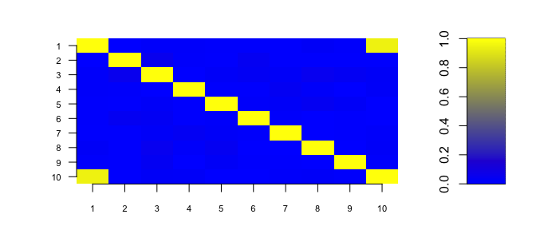

```r
plot(abs(corr_mean))
```

```r
coef_sum=rep(0,length(group))
names(coef_sum)<-paste("x",1:length(group),sep="")
error_counter=0
for(i in 1:NDatasets){
tempdf=data.frame(cbind(Y=get(paste("DATA_exemple1_nb_",i,sep=""))$Y,
                        get(paste("DATA_exemple1_nb_",i,sep=""))$X))
tempcoef=coef(lm(Y~.-1,data=tempdf))
if(is.null(tempcoef)){
cat("Error in lm fit, skip coefficients\n")
error_counter=error_counter+1
  } else{
coef_sum=coef_sum+abs(tempcoef)
}
}
error_counter
```

```
#> [1] 0
```

```r
coef_mean=coef_sum/NDatasets
```

All fits were sucessful. Then we display and plot that the mean coefficient vector values.

```r
coef_mean
```

```
#>           x1           x2           x3           x4           x5           x6
#> 1.508327e+00 1.518967e+00 1.491694e+00 1.437883e-15 1.857978e-15 2.524863e-15
#>           x7           x8           x9          x10
#> 1.848380e-15 2.314167e-15 2.601342e-15 6.269818e-15
```

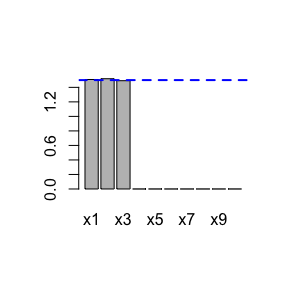

```r
barplot(coef_mean)
abline(h=(minB+maxB)/2,lwd=2,lty=2,col="blue")
```

```r
set.seed(3141)
stn <- 5000
for(i in 1:NDatasets){
X<-simulation_X(N,CM)
assign(paste("DATA_exemple1_bis_nb_",i,sep=""),simulation_DATA(X,supp,minB,maxB,stn))
}
```

Since it is the same explanatory dataset for response generation, we can compare the $\sigma$ between those $NDatasets=200$ datasets.

```r
stn_ratios=rep(0,NDatasets)
for(i in 1:NDatasets){
stn_ratios[i]<-get(paste("DATA_exemple1_nb_",i,sep=""))$sigma/
  get(paste("DATA_exemple1_bis_nb_",i,sep=""))$sigma
}
all(sapply(stn_ratios,all.equal,10))
```

```
#> [1] TRUE
```

All the ratios are equal to 10 as anticipated.

Since, the correlation structure is the same as before, we do not need to check it again. As befor, we infer the coefficients values of a linear model using the `lm` function.

```r
coef_sum_bis=rep(0,length(group))
names(coef_sum_bis)<-paste("x",1:length(group),sep="")
error_counter_bis=0
for(i in 1:NDatasets){
tempdf=data.frame(cbind(Y=get(paste("DATA_exemple1_bis_nb_",i,sep=""))$Y,
                        get(paste("DATA_exemple1_bis_nb_",i,sep=""))$X))
tempcoef=coef(lm(Y~.-1,data=tempdf))
if(is.null(tempcoef)){
cat("Error in lm fit, skip coefficients\n")
error_counter_bis=error_counte_bisr+1
  } else{
coef_sum_bis=coef_sum_bis+abs(tempcoef)
}
}
error_counter_bis
```

```
#> [1] 0
```

```r
coef_mean_bis=coef_sum_bis/NDatasets
```

```r
coef_mean_bis
```

```
#>           x1           x2           x3           x4           x5           x6
#> 1.508327e+00 1.518967e+00 1.491694e+00 1.437883e-15 1.857978e-15 2.524863e-15
#>           x7           x8           x9          x10
#> 1.848380e-15 2.314167e-15 2.601342e-15 6.269818e-15
```

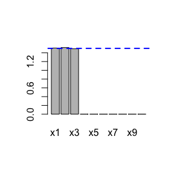

```r
barplot(coef_mean_bis)
abline(h=(minB+maxB)/2,lwd=2,lty=2,col="blue")
```

The simulation process looks sucessfull. What are the confidence indices for those variables?

# Second example

## Aim

We want to creates $NDatasets=200$ datasets with $\textrm{length}(group)=50$ variables and $N=20$ observations. In that example we want $1$ group:

- $x_1$, , $x_{50}$ belong to the same group and the intra-group Pearson correlation for this group is equal to $.5$.
- only the first five variables $x_1$, , $x_{5}$ are explanatory variables for the response.

## Correlation structure

```r
group<-rep(1,50) #50 variables
cor_group<-rep(0.5,1)
```

## Explanatory variables and response

```r
set.seed(3141)
N<-20
supp<-c(1,1,1,1,1,rep(0,45))
minB<-1
maxB<-2
stn<-50
for(i in 1:200){
C<-simulation_cor(group,cor_group)
X<-simulation_X(N,C)
assign(paste("DATA_exemple2_nb_",i,sep=""),simulation_DATA(X,supp,minB,maxB,stn))
}
```

## Checks

We now check the correlation structure of the explanatory variable. First we compute the mean correlation matrix.

```r
corr_sum=matrix(0,length(group),length(group))
for(i in 1:NDatasets){
corr_sum=corr_sum+cor(get(paste("DATA_exemple2_nb_",i,sep=""))$X)
}
corr_mean=corr_sum/NDatasets
```

Then we display and plot that the mean correlation matrix.

```r
corr_mean[1:10,1:10]
```

```
#>            [,1]      [,2]      [,3]      [,4]      [,5]      [,6]      [,7]
#>  [1,] 1.0000000 0.4875195 0.4774265 0.4739869 0.4796578 0.4927521 0.4898313
#>  [2,] 0.4875195 1.0000000 0.4750680 0.4940743 0.4842295 0.4988293 0.4937678
#>  [3,] 0.4774265 0.4750680 1.0000000 0.4799584 0.4690139 0.4831884 0.4765315
#>  [4,] 0.4739869 0.4940743 0.4799584 1.0000000 0.4990798 0.4995625 0.4928739
#>  [5,] 0.4796578 0.4842295 0.4690139 0.4990798 1.0000000 0.4890548 0.4839137
#>  [6,] 0.4927521 0.4988293 0.4831884 0.4995625 0.4890548 1.0000000 0.4980120
#>  [7,] 0.4898313 0.4937678 0.4765315 0.4928739 0.4839137 0.4980120 1.0000000
#>  [8,] 0.4786241 0.4904904 0.4871110 0.4799335 0.4807772 0.5015775 0.4766888
#>  [9,] 0.4821186 0.4801270 0.4648431 0.4774361 0.4657147 0.4942747 0.4786140
#> [10,] 0.4875410 0.4690954 0.4669033 0.4832185 0.4781301 0.4873754 0.4825714
#>            [,8]      [,9]     [,10]
#>  [1,] 0.4786241 0.4821186 0.4875410
#>  [2,] 0.4904904 0.4801270 0.4690954
#>  [3,] 0.4871110 0.4648431 0.4669033
#>  [4,] 0.4799335 0.4774361 0.4832185
#>  [5,] 0.4807772 0.4657147 0.4781301
#>  [6,] 0.5015775 0.4942747 0.4873754
#>  [7,] 0.4766888 0.4786140 0.4825714
#>  [8,] 1.0000000 0.4783224 0.4832658
#>  [9,] 0.4783224 1.0000000 0.4769654
#> [10,] 0.4832658 0.4769654 1.0000000
```

```r
plot(abs(corr_mean))
```

[output not shown]

```r
coef_sum=rep(0,length(group))
coef_lasso_sum=rep(0,length(group))
names(coef_sum)<-paste("x",1:length(group),sep="")
names(coef_lasso_sum)<-paste("x",1:length(group),sep="")
error_counter=0
for(i in 1:NDatasets){
tempdf=data.frame(cbind(Y=get(paste("DATA_exemple2_nb_",i,sep=""))$Y,
                        get(paste("DATA_exemple2_nb_",i,sep=""))$X))
tempcoef=coef(lm(Y~.-1,data=tempdf))
require(lars)
lasso.1 <- lars::lars(x=get(paste("DATA_exemple2_nb_",i,sep=""))$X,
              y=get(paste("DATA_exemple2_nb_",i,sep=""))$Y, type="lasso",
              trace=FALSE, normalize=FALSE, intercept = FALSE)
# cv.lars() uses crossvalidation to estimate optimal position in path
cv.lasso.1 <- lars::cv.lars(x=get(paste("DATA_exemple2_nb_",i,sep=""))$X,
              y=get(paste("DATA_exemple2_nb_",i,sep=""))$Y,
              plot.it=FALSE, type="lasso")
# Use the "+1SE rule" to find best model:
#    Take the min CV and add its SE ("limit").
#    Find smallest model that has its own CV within this limit (at "s.cv.1")
limit <- min(cv.lasso.1$cv) + cv.lasso.1$cv.error[which.min(cv.lasso.1$cv)]
s.cv.1 <- cv.lasso.1$index[min(which(cv.lasso.1$cv < limit))]
# Print out coefficients at optimal s.
coef_lasso_sum=coef_lasso_sum+abs(coef(lasso.1, s=s.cv.1, mode="fraction"))
if(is.null(tempcoef)){
cat("Error in lm fit, skip coefficients\n")
error_counter=error_counter+1
  } else{
coef_sum=coef_sum+abs(tempcoef)
}
}
error_counter
```

```
#> [1] 0
```

```r
coef_mean=coef_sum/NDatasets
coef_lasso_mean=coef_lasso_sum/NDatasets
```

With regular least squares and lasso estimators all fits were sucessful, yet only 20 variables coefficients could be estimated with regular least squares estimates for the linear model. Then we display and plot that the mean coefficient vector values for the least squares estimates.

```r
coef_mean
```

```
#>           x1           x2           x3           x4           x5           x6
#> 1.500084e+00 1.492942e+00 1.496050e+00 1.528043e+00 1.497537e+00 2.577168e-15
#>           x7           x8           x9          x10          x11          x12
#> 6.820231e-15 3.386509e-15 4.297997e-15 7.216331e-15 3.528058e-15 1.001056e-14
#>          x13          x14          x15          x16          x17          x18
#> 6.068207e-15 9.640427e-15 5.351262e-15 9.276245e-15 5.295417e-15 8.227904e-15
#>          x19          x20          x21          x22          x23          x24
#> 5.860229e-15 4.724224e-15           NA           NA           NA           NA
#>          x25          x26          x27          x28          x29          x30
#>           NA           NA           NA           NA           NA           NA
#>          x31          x32          x33          x34          x35          x36
#>           NA           NA           NA           NA           NA           NA
#>          x37          x38          x39          x40          x41          x42
#>           NA           NA           NA           NA           NA           NA
#>          x43          x44          x45          x46          x47          x48
#>           NA           NA           NA           NA           NA           NA
#>          x49          x50
#>           NA           NA
```

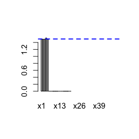

```r
barplot(coef_mean)
abline(h=(minB+maxB)/2,lwd=2,lty=2,col="blue")
```

```r
coef_lasso_mean
```

```
#>          x1          x2          x3          x4          x5          x6
#> 1.042797240 1.024351404 1.057189635 1.059918050 0.994404788 0.007811962
#>          x7          x8          x9         x10         x11         x12
#> 0.011009602 0.009950373 0.013005461 0.018532747 0.012150834 0.023340488
#>         x13         x14         x15         x16         x17         x18
#> 0.012180014 0.008609733 0.011696843 0.007597800 0.010060507 0.015854369
#>         x19         x20         x21         x22         x23         x24
#> 0.006510553 0.014711703 0.011361285 0.012992170 0.014313271 0.006087609
#>         x25         x26         x27         x28         x29         x30
#> 0.011454684 0.013015273 0.014588342 0.006003267 0.003791722 0.005444574
#>         x31         x32         x33         x34         x35         x36
#> 0.013608283 0.009956626 0.017375834 0.008338741 0.004911942 0.010809073
#>         x37         x38         x39         x40         x41         x42
#> 0.011337145 0.007562486 0.005735180 0.008270178 0.008649584 0.004325733
#>         x43         x44         x45         x46         x47         x48
#> 0.014522021 0.014055931 0.002711682 0.006649858 0.004087594 0.011020089
#>         x49         x50
#> 0.003891170 0.011052097
```

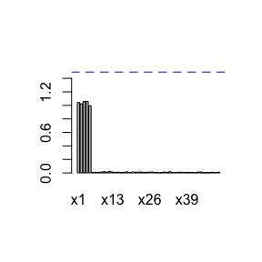

```r
barplot(coef_lasso_mean,ylim=c(0,1.5))
abline(h=(minB+maxB)/2,lwd=2,lty=2,col="blue")
```

The simulation process looks sucessfull: the lasso estimates retrives mostly the correct variables, yet the other ones are also selected sometimes. What are the confidence indices for those variables?

# Third Example

## Aim

We want to creates $NDatasets=200$ datasets with $\textrm{length}(supp)=100$ variables and $N=24$ observations. In that example we use real data for the `X` variables that we sample from all the $1650$ probesets that are differentially expressed between the two conditions US and S. The main interest of that simulation is that the correlation structure of the `X` dataset will be a real one.

## Data and response generations

First retrieve the datasets and get the differentially expressed probesets. Run the code to get additionnal plots.

```r
require(CascadeData)
data(micro_S)
data(micro_US)
require(Cascade)
micro_US<-as.micro_array(micro_US,c(60,90,240,390),6)
micro_S<-as.micro_array(micro_S,c(60,90,240,390),6)
S<-geneSelection(list(micro_S,micro_US),list("condition",c(1,2),1),-1)
Sel<-micro_S@microarray[S@name,]
```

```r
summary(S)
```

```
#>    N1_US_T60           N1_US_T90          N1_US_T210         N1_US_T390
#>  Min.   :-3.445442   Min.   :-4.28468   Min.   :-5.08296   Min.   :-4.68431
#>  1st Qu.:-0.142287   1st Qu.:-0.07960   1st Qu.:-0.78755   1st Qu.:-0.62401
#>  Median :-0.033095   Median : 0.10331   Median : 0.39450   Median : 0.32171
#>  Mean   :-0.002321   Mean   : 0.07994   Mean   : 0.04299   Mean   : 0.08204
#>  3rd Qu.: 0.110515   3rd Qu.: 0.28131   3rd Qu.: 0.78988   3rd Qu.: 0.66365
#>  Max.   : 3.471966   Max.   : 2.93563   Max.   : 3.93893   Max.   : 3.18762
#>    N2_US_T60         N2_US_T90          N2_US_T210         N2_US_T390
#>  Min.   :-2.6027   Min.   :-3.37588   Min.   :-3.87950   Min.   :-4.61130
#>  1st Qu.: 0.1760   1st Qu.:-0.22368   1st Qu.:-0.51207   1st Qu.:-0.36024
#>  Median : 0.3461   Median :-0.09522   Median : 0.25689   Median : 0.22635
#>  Mean   : 0.3528   Mean   :-0.11100   Mean   : 0.03797   Mean   : 0.03828
#>  3rd Qu.: 0.5404   3rd Qu.: 0.02934   3rd Qu.: 0.57309   3rd Qu.: 0.43864
#>  Max.   : 3.1862   Max.   : 3.10336   Max.   : 3.63905   Max.   : 2.76737
#>    N3_US_T60           N3_US_T90          N3_US_T210         N3_US_T390
#>  Min.   :-3.550140   Min.   :-4.36036   Min.   :-5.67972   Min.   :-4.5060
#>  1st Qu.:-0.146245   1st Qu.:-0.12487   1st Qu.:-1.15095   1st Qu.:-0.4787
#>  Median : 0.017224   Median : 0.11684   Median : 0.27993   Median : 0.4759
#>  Mean   :-0.002654   Mean   : 0.01882   Mean   :-0.06901   Mean   : 0.2070
#>  3rd Qu.: 0.185573   3rd Qu.: 0.29070   3rd Qu.: 0.80863   3rd Qu.: 0.7967
#>  Max.   : 2.692240   Max.   : 3.98065   Max.   : 3.56704   Max.   : 3.7395
#>    N4_US_T60          N4_US_T90          N4_US_T210         N4_US_T390
#>  Min.   :-2.25607   Min.   :-3.60640   Min.   :-3.99245   Min.   :-3.25596
#>  1st Qu.:-0.10098   1st Qu.:-0.03933   1st Qu.:-0.44414   1st Qu.:-0.28561
#>  Median :-0.02510   Median : 0.10412   Median : 0.05968   Median : 0.01639
#>  Mean   :-0.04386   Mean   : 0.03840   Mean   :-0.12505   Mean   :-0.07290
#>  3rd Qu.: 0.04279   3rd Qu.: 0.21634   3rd Qu.: 0.24426   3rd Qu.: 0.17245
#>  Max.   : 2.78691   Max.   : 3.39207   Max.   : 2.73437   Max.   : 3.56718
#>    N5_US_T60           N5_US_T90          N5_US_T210         N5_US_T390
#>  Min.   :-2.734367   Min.   :-3.32569   Min.   :-3.63519   Min.   :-3.42995
#>  1st Qu.: 0.007341   1st Qu.:-0.13749   1st Qu.:-0.53121   1st Qu.:-0.23822
#>  Median : 0.120659   Median : 0.02666   Median : 0.18888   Median : 0.24203
#>  Mean   : 0.082653   Mean   :-0.03708   Mean   :-0.06209   Mean   : 0.09684
#>  3rd Qu.: 0.210589   3rd Qu.: 0.14035   3rd Qu.: 0.41754   3rd Qu.: 0.43804
#>  Max.   : 2.890372   Max.   : 3.21219   Max.   : 3.70482   Max.   : 3.10234
#>    N6_US_T60           N6_US_T90           N6_US_T210         N6_US_T390
#>  Min.   :-3.160354   Min.   :-3.261297   Min.   :-3.47610   Min.   :-4.15575
#>  1st Qu.:-0.093522   1st Qu.:-0.151623   1st Qu.:-0.62330   1st Qu.:-0.44959
#>  Median :-0.006127   Median : 0.068895   Median : 0.37171   Median : 0.23296
#>  Mean   :-0.031932   Mean   : 0.005802   Mean   : 0.06757   Mean   : 0.05379
#>  3rd Qu.: 0.075654   3rd Qu.: 0.238649   3rd Qu.: 0.66546   3rd Qu.: 0.49867
#>  Max.   : 3.011000   Max.   : 2.803360   Max.   : 4.00612   Max.   : 3.31323
```

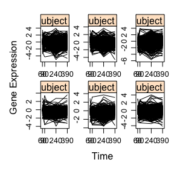

```r
plot(S)
```

Generates the datasets sampling for each of them 100 probesets expressions among the 1650 that were selected and linking the response to the expressions of the first five probesets.

```r
set.seed(3141)
supp<-c(1,1,1,1,1,rep(0,95))
minB<-1
maxB<-2
stn<-50
NDatasets=200

for(i in 1:NDatasets){
X<-t(as.matrix(Sel[sample(1:nrow(Sel),100),]))
Xnorm<-t(t(X)/sqrt(colSums(X*X)))
assign(paste("DATA_exemple3_nb_",i,sep=""),simulation_DATA(Xnorm,supp,minB,maxB,stn))
}
```

## Checks

Here are the plots of an example of correlation structure, namely for `DATA_exemple3_nb_200$X`. Run the code to get the graphics.

```r
plot(cor(Xnorm))
mixOmics::cim(cor(Xnorm))
```

```r
coef_sum=rep(0,length(supp))
coef_lasso_sum=rep(0,length(supp))
names(coef_sum)<-paste("x",1:length(supp),sep="")
names(coef_lasso_sum)<-paste("x",1:length(supp),sep="")
error_counter=0
for(i in 1:NDatasets){
tempdf=data.frame(cbind(Y=get(paste("DATA_exemple3_nb_",i,sep=""))$Y,
                        get(paste("DATA_exemple3_nb_",i,sep=""))$X))
tempcoef=coef(lm(Y~.-1,data=tempdf))
require(lars)
lasso.1 <- lars::lars(x=get(paste("DATA_exemple3_nb_",i,sep=""))$X,
              y=get(paste("DATA_exemple3_nb_",i,sep=""))$Y, type="lasso",
              trace=FALSE, normalize=FALSE, intercept = FALSE)
# cv.lars() uses crossvalidation to estimate optimal position in path
cv.lasso.1 <- lars::cv.lars(x=get(paste("DATA_exemple3_nb_",i,sep=""))$X,
              y=get(paste("DATA_exemple3_nb_",i,sep=""))$Y,
              plot.it=FALSE, normalize=FALSE, intercept = FALSE, type="lasso")
# Use the "+1SE rule" to find best model:
#    Take the min CV and add its SE ("limit").
#    Find smallest model that has its own CV within this limit (at "s.cv.1")
limit <- min(cv.lasso.1$cv) + cv.lasso.1$cv.error[which.min(cv.lasso.1$cv)]
s.cv.1 <- cv.lasso.1$index[min(which(cv.lasso.1$cv < limit))]
# Print out coefficients at optimal s.
coef_lasso_sum=coef_lasso_sum+abs(coef(lasso.1, s=s.cv.1, mode="fraction"))
if(is.null(tempcoef)){
cat("Error in lm fit, skip coefficients\n")
error_counter=error_counter+1
  } else{
coef_sum=coef_sum+abs(tempcoef)
}
}
error_counter
```

```
#> [1] 0
```

```r
coef_mean=coef_sum/NDatasets
coef_lasso_mean=coef_lasso_sum/NDatasets
```

```r
coef_mean
```

```
#>           x1           x2           x3           x4           x5           x6
#> 1.457741e+00 1.488627e+00 1.503719e+00 1.506939e+00 1.481887e+00 1.463622e-14
#>           x7           x8           x9          x10          x11          x12
#> 1.250379e-14 1.241973e-14 1.154723e-14 9.181216e-15 1.426020e-14 1.400520e-14
#>          x13          x14          x15          x16          x17          x18
#> 1.376739e-14 1.075624e-14 1.417228e-14 1.173325e-14 1.083780e-14 1.541663e-14
#>          x19          x20          x21          x22          x23          x24
#> 1.311993e-14 1.272276e-14 1.255378e-14 9.132597e-15 1.242458e-14 1.161036e-14
#>          x25          x26          x27          x28          x29          x30
#>           NA           NA           NA           NA           NA           NA
#>          x31          x32          x33          x34          x35          x36
#>           NA           NA           NA           NA           NA           NA
#>          x37          x38          x39          x40          x41          x42
#>           NA           NA           NA           NA           NA           NA
#>          x43          x44          x45          x46          x47          x48
#>           NA           NA           NA           NA           NA           NA
#>          x49          x50          x51          x52          x53          x54
#>           NA           NA           NA           NA           NA           NA
#>          x55          x56          x57          x58          x59          x60
#>           NA           NA           NA           NA           NA           NA
#>          x61          x62          x63          x64          x65          x66
#>           NA           NA           NA           NA           NA           NA
#>          x67          x68          x69          x70          x71          x72
#>           NA           NA           NA           NA           NA           NA
#>          x73          x74          x75          x76          x77          x78
#>           NA           NA           NA           NA           NA           NA
#>          x79          x80          x81          x82          x83          x84
#>           NA           NA           NA           NA           NA           NA
#>          x85          x86          x87          x88          x89          x90
#>           NA           NA           NA           NA           NA           NA
#>          x91          x92          x93          x94          x95          x96
#>           NA           NA           NA           NA           NA           NA
#>          x97          x98          x99         x100
#>           NA           NA           NA           NA
```

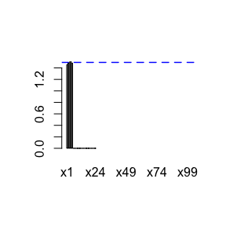

```r
barplot(coef_mean)
abline(h=(minB+maxB)/2,lwd=2,lty=2,col="blue")
```

```r
coef_lasso_mean
```

```
#>          x1          x2          x3          x4          x5          x6
#> 0.702285013 0.723440505 0.815188377 0.750116968 0.755956082 0.024137291
#>          x7          x8          x9         x10         x11         x12
#> 0.015683388 0.010568410 0.011885616 0.014090781 0.021003812 0.011734542
#>         x13         x14         x15         x16         x17         x18
#> 0.013886806 0.022119874 0.014456640 0.015433682 0.023878773 0.016755598
#>         x19         x20         x21         x22         x23         x24
#> 0.021327747 0.013616459 0.019931987 0.018892285 0.014078848 0.023451766
#>         x25         x26         x27         x28         x29         x30
#> 0.021368384 0.018488386 0.012237622 0.012374498 0.016539558 0.032588868
#>         x31         x32         x33         x34         x35         x36
#> 0.017420066 0.025462243 0.010716574 0.008629069 0.012718865 0.026893311
#>         x37         x38         x39         x40         x41         x42
#> 0.012677017 0.017008703 0.015438845 0.020113071 0.015363207 0.021437081
#>         x43         x44         x45         x46         x47         x48
#> 0.015004240 0.023183989 0.009375730 0.028538708 0.010589785 0.012912658
#>         x49         x50         x51         x52         x53         x54
#> 0.020992716 0.022101301 0.019696163 0.017486521 0.012797403 0.017440036
#>         x55         x56         x57         x58         x59         x60
#> 0.021883771 0.020960943 0.017123111 0.007463007 0.013487264 0.020183239
#>         x61         x62         x63         x64         x65         x66
#> 0.020290916 0.017386233 0.015246366 0.019681685 0.011710219 0.012215833
#>         x67         x68         x69         x70         x71         x72
#> 0.016924463 0.019222570 0.022233419 0.012180260 0.023211104 0.021088886
#>         x73         x74         x75         x76         x77         x78
#> 0.019976721 0.012413973 0.009042247 0.024407614 0.011452036 0.022174681
#>         x79         x80         x81         x82         x83         x84
#> 0.023751515 0.012819697 0.014332526 0.014435944 0.021011010 0.010708244
#>         x85         x86         x87         x88         x89         x90
#> 0.016372220 0.013674264 0.024953334 0.017955954 0.016143853 0.023553511
#>         x91         x92         x93         x94         x95         x96
#> 0.023766936 0.011696891 0.010349792 0.012281145 0.019443916 0.019066927
#>         x97         x98         x99        x100
#> 0.016262147 0.015455002 0.012684836 0.018997083
```

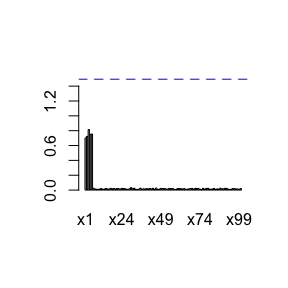

```r
barplot(coef_lasso_mean,ylim=c(0,1.5))
abline(h=(minB+maxB)/2,lwd=2,lty=2,col="blue")
```

The simulation process looks sucessfull: the lasso estimates retrives mostly the correct variables, yet the other ones are also selected sometimes. What are the confidence indices for those variables?

# Fourth Example

## Aim

We want to creates $NDatasets=101$ datasets with $\textrm{length}(supp)=100$ variables and $N=18$ observations. In that example we use real data for the variables that are the $101$ probesets that are the more differentially expressed between the two conditions US and S. We create $101$ datasets by leaving one of the variables out each time and using it as the response that shall be predicted. We also only use for the explanatory variables the observations that are the measurements for the 1st, 2nd and 3rd timepoints and for the responses the observations that are the measurements of the same variables for the 2nd, 3rd and 4th timepoints. The main interest of that simulation is that the correlation structure of the `X` dataset will be a real one and that it is a typical setting for cascade network reverse-engineering in genomics or proteomics, see the `Cascade` package for more details.

## Data and response generations

First retrieve the datasets and get the differentially expressed probesets. Run the code to get additionnal plots.

```r
require(CascadeData)
data(micro_S)
data(micro_US)
require(Cascade)
micro_US<-as.micro_array(micro_US,c(60,90,240,390),6)
micro_S<-as.micro_array(micro_S,c(60,90,240,390),6)
S<-geneSelection(list(micro_S,micro_US),list("condition",c(1,2),1),101)
Sel<-micro_S@microarray[S@name,]
```

```r
summary(S)
```

```
#>    N1_US_T60          N1_US_T90         N1_US_T210        N1_US_T390
#>  Min.   :-2.86440   Min.   :-4.2847   Min.   :-4.5591   Min.   :-3.5620
#>  1st Qu.:-0.27855   1st Qu.:-0.5322   1st Qu.:-1.5662   1st Qu.:-1.0324
#>  Median :-0.11420   Median : 0.0229   Median :-0.8926   Median :-0.3158
#>  Mean   :-0.25760   Mean   :-0.2284   Mean   :-0.4651   Mean   :-0.2925
#>  3rd Qu.: 0.03457   3rd Qu.: 0.3970   3rd Qu.: 1.0840   3rd Qu.: 0.6128
#>  Max.   : 0.59866   Max.   : 1.5979   Max.   : 1.8577   Max.   : 2.6810
#>    N2_US_T60         N2_US_T90          N2_US_T210        N2_US_T390
#>  Min.   :-2.0267   Min.   :-3.37588   Min.   :-2.9783   Min.   :-2.3026
#>  1st Qu.: 0.1515   1st Qu.:-0.44572   1st Qu.:-1.2720   1st Qu.:-0.6091
#>  Median : 0.3207   Median :-0.19104   Median :-0.6199   Median :-0.1629
#>  Mean   : 0.2513   Mean   :-0.34924   Mean   :-0.4245   Mean   :-0.1582
#>  3rd Qu.: 0.5239   3rd Qu.: 0.01764   3rd Qu.: 0.6264   3rd Qu.: 0.4601
#>  Max.   : 1.4069   Max.   : 3.04749   Max.   : 1.7326   Max.   : 0.8499
#>    N3_US_T60          N3_US_T90         N3_US_T210        N3_US_T390
#>  Min.   :-3.31723   Min.   :-4.3604   Min.   :-5.3671   Min.   :-4.2055
#>  1st Qu.:-0.49979   1st Qu.:-1.2628   1st Qu.:-1.9470   1st Qu.:-1.0143
#>  Median :-0.06299   Median :-0.4540   Median :-1.0742   Median :-0.3669
#>  Mean   :-0.29855   Mean   :-0.5145   Mean   :-0.6951   Mean   :-0.2288
#>  3rd Qu.: 0.22531   3rd Qu.: 0.5196   3rd Qu.: 1.0217   3rd Qu.: 0.8482
#>  Max.   : 0.94585   Max.   : 1.7065   Max.   : 2.2100   Max.   : 1.3611
#>    N4_US_T60          N4_US_T90         N4_US_T210        N4_US_T390
#>  Min.   :-1.82903   Min.   :-3.6064   Min.   :-3.1968   Min.   :-3.2560
#>  1st Qu.:-0.20932   1st Qu.:-0.6953   1st Qu.:-1.0210   1st Qu.:-0.6339
#>  Median :-0.05962   Median :-0.1442   Median :-0.4632   Median :-0.2058
#>  Mean   :-0.15230   Mean   :-0.2774   Mean   :-0.5000   Mean   :-0.3218
#>  3rd Qu.: 0.03940   3rd Qu.: 0.4080   3rd Qu.: 0.2534   3rd Qu.: 0.1055
#>  Max.   : 1.90954   Max.   : 1.8458   Max.   : 1.8281   Max.   : 1.0341
#>    N5_US_T60          N5_US_T90         N5_US_T210        N5_US_T390
#>  Min.   :-2.54975   Min.   :-3.3257   Min.   :-3.4105   Min.   :-1.9624
#>  1st Qu.:-0.20984   1st Qu.:-0.7611   1st Qu.:-1.3906   1st Qu.:-0.6373
#>  Median : 0.08285   Median :-0.2723   Median :-0.6157   Median :-0.1902
#>  Mean   :-0.10242   Mean   :-0.3500   Mean   :-0.5298   Mean   :-0.1621
#>  3rd Qu.: 0.23124   3rd Qu.: 0.3838   3rd Qu.: 0.5024   3rd Qu.: 0.4586
#>  Max.   : 1.33829   Max.   : 0.8780   Max.   : 1.2040   Max.   : 1.2305
#>    N6_US_T60          N6_US_T90         N6_US_T210        N6_US_T390
#>  Min.   :-3.16035   Min.   :-3.2613   Min.   :-3.4761   Min.   :-3.1015
#>  1st Qu.:-0.41977   1st Qu.:-1.1226   1st Qu.:-1.3108   1st Qu.:-0.7930
#>  Median :-0.09151   Median :-0.3160   Median :-0.7274   Median :-0.2896
#>  Mean   :-0.30570   Mean   :-0.4130   Mean   :-0.4159   Mean   :-0.2531
#>  3rd Qu.: 0.08889   3rd Qu.: 0.4766   3rd Qu.: 0.8294   3rd Qu.: 0.4834
#>  Max.   : 0.61310   Max.   : 1.7452   Max.   : 1.4716   Max.   : 1.1834
```

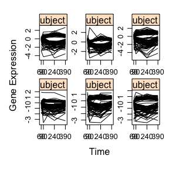

```r
plot(S)
```

```r
suppt<-rep(1:4,6)
supp<-c(1,1,1,1,1,rep(0,95)) #not used since we use one of the probeset expressions as response
minB<-1 #not used since we use one of the probeset expressions as response
maxB<-2 #not used since we use one of the probeset expressions as response
stn<-50 #not used since we use one of the probeset expressions as response
NDatasets<-101

set.seed(3141)
for(i in 1:NDatasets){
  #the explanatory variables are the values for the 1st, 2nd and 3rd timepoints
  X<-t(as.matrix(Sel[-i,suppt!=4]))
  Xnorm<-t(t(X)/sqrt(colSums(X*X)))
  DATA<-simulation_DATA(Xnorm,supp,minB,maxB,stn)
  #the reponses are the values for the 2nd, 3rd and 4th timepoints
  DATA$Y<-as.vector(t(Sel[i,suppt!=1]))
  assign(paste("DATA_exemple4_nb_",i,sep=""),DATA)
  rm(DATA)
}
```

## Checks

```r
plot(cor(Xnorm))
mixOmics::cim(cor(Xnorm))
```

```r
coef_sum=rep(0,length(supp)+1)
coef_lasso_sum=rep(0,length(supp)+1)
names(coef_sum)<-paste("x",1:(length(supp)+1),sep="")
names(coef_lasso_sum)<-paste("x",1:(length(supp)+1),sep="")
error_counter=0
for(i in 1:NDatasets){
tempdf=data.frame(cbind(Y=get(paste("DATA_exemple4_nb_",i,sep=""))$Y,
                        get(paste("DATA_exemple4_nb_",i,sep=""))$X))
tempcoef=coef(lm(Y~.-1,data=tempdf))
require(lars)
lasso.1 <- lars::lars(x=get(paste("DATA_exemple4_nb_",i,sep=""))$X,
              y=get(paste("DATA_exemple4_nb_",i,sep=""))$Y, type="lasso",
              trace=FALSE, normalize=FALSE, intercept = FALSE)
# cv.lars() uses crossvalidation to estimate optimal position in path
cv.lasso.1 <- lars::cv.lars(x=get(paste("DATA_exemple4_nb_",i,sep=""))$X,
              y=get(paste("DATA_exemple4_nb_",i,sep=""))$Y,
              plot.it=FALSE, normalize=FALSE, intercept = FALSE, type="lasso")
# Use the "+1SE rule" to find best model:
#    Take the min CV and add its SE ("limit").
#    Find smallest model that has its own CV within this limit (at "s.cv.1")
limit <- min(cv.lasso.1$cv) + cv.lasso.1$cv.error[which.min(cv.lasso.1$cv)]
s.cv.1 <- cv.lasso.1$index[min(which(cv.lasso.1$cv < limit))]
# Print out coefficients at optimal s.
coef_lasso_sum[-i]=coef_lasso_sum[-i]+abs(coef(lasso.1, s=s.cv.1, mode="fraction"))
if(is.null(tempcoef)){
cat("Error in lm fit, skip coefficients\n")
error_counter=error_counter+1
  } else{
coef_sum[-i]=coef_sum[-i]+abs(tempcoef)
}
}
error_counter
```

```
#> [1] 0
```

```r
coef_mean=coef_sum/NDatasets
coef_lasso_mean=coef_lasso_sum/NDatasets
```

```r
head(coef_mean, 40)
```

```
#>       x1       x2       x3       x4       x5       x6       x7       x8
#> 2248.272 2853.555 1621.780 3766.243 3261.185 2951.494 2532.662 1849.877
#>       x9      x10      x11      x12      x13      x14      x15      x16
#> 7123.990 4535.791 4758.085 2069.225 1517.617 5293.455 1503.779 1328.183
#>      x17      x18      x19      x20      x21      x22      x23      x24
#> 7760.637 2140.740       NA       NA       NA       NA       NA       NA
#>      x25      x26      x27      x28      x29      x30      x31      x32
#>       NA       NA       NA       NA       NA       NA       NA       NA
#>      x33      x34      x35      x36      x37      x38      x39      x40
#>       NA       NA       NA       NA       NA       NA       NA       NA
```

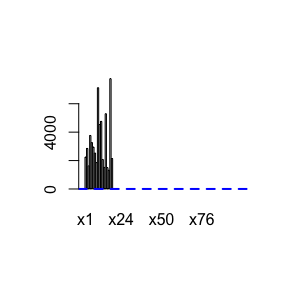

```r
barplot(coef_mean)
abline(h=(minB+maxB)/2,lwd=2,lty=2,col="blue")
```

```r
head(coef_lasso_mean, 40)
```

```
#>           x1           x2           x3           x4           x5           x6
#>  15.54572730  14.58227728   4.95845727   0.46353875   1.00330697  29.55699720
#>           x7           x8           x9          x10          x11          x12
#>  21.34444981   0.83829989  18.81081187  17.57661299   2.75710443  13.09893938
#>          x13          x14          x15          x16          x17          x18
#>  31.33928841  16.54387748   5.30914304   0.00000000   1.99138104   0.00000000
#>          x19          x20          x21          x22          x23          x24
#>   4.35699583   0.75449031  44.78090867  18.67703579   0.92835303   2.91925792
#>          x25          x26          x27          x28          x29          x30
#>  17.77204643   0.00000000   0.00000000   0.06240116  13.18244817  23.56341540
#>          x31          x32          x33          x34          x35          x36
#>  16.98378204 102.13843333  59.14623441  36.64445640   0.00000000  59.82919657
#>          x37          x38          x39          x40
#>  44.57764098   0.00000000   0.00000000   0.00000000
```

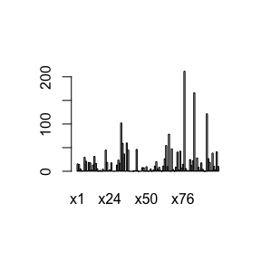

```r
barplot(coef_lasso_mean)
```

Some probesets seem explanatory for many other ones (=hubs). What are the confidence indices for those variables?

# Fifth Example

## Aim

- $x_1$, , $x_{500}$ belong to the same group and the intra-group Pearson correlation for this group is equal to $.5$.
- only the first five variables $x_1$, , $x_{5}$ are explanatory variables for the response.

## Correlation structure

```r
  group<-rep(1,500) #500 variables
  cor_group<-rep(0.5,1)
```

## Explanatory variables and response

```r
set.seed(3141)
N<-25
supp<-c(1,1,1,1,1,rep(0,495))
minB<-1
maxB<-2
stn<-50
for(i in 1:NDatasets){
  C<-simulation_cor(group,cor_group)
  X<-simulation_X(N,C)
  assign(paste("DATA_exemple5_nb_",i,sep=""),simulation_DATA(X,supp,minB,maxB,stn))
}
```

## Checks

We now check the correlation structure of the explanatory variable. First we compute the mean correlation matrix.

```r
corr_sum=matrix(0,length(group),length(group))
for(i in 1:NDatasets){
corr_sum=corr_sum+cor(get(paste("DATA_exemple5_nb_",i,sep=""))$X)
}
corr_mean=corr_sum/NDatasets
```

Then we display and plot that the mean correlation matrix.

```r
corr_mean[1:10,1:10]
```

```
#>            [,1]      [,2]      [,3]      [,4]      [,5]      [,6]      [,7]
#>  [1,] 1.0000000 0.4684444 0.4944331 0.4628645 0.4961487 0.4956996 0.4654665
#>  [2,] 0.4684444 1.0000000 0.5102506 0.5026134 0.4960774 0.4948349 0.4813972
#>  [3,] 0.4944331 0.5102506 1.0000000 0.4853991 0.4907725 0.5089649 0.4925889
#>  [4,] 0.4628645 0.5026134 0.4853991 1.0000000 0.4670240 0.4837113 0.4948130
#>  [5,] 0.4961487 0.4960774 0.4907725 0.4670240 1.0000000 0.4932811 0.4723250
#>  [6,] 0.4956996 0.4948349 0.5089649 0.4837113 0.4932811 1.0000000 0.4759705
#>  [7,] 0.4654665 0.4813972 0.4925889 0.4948130 0.4723250 0.4759705 1.0000000
#>  [8,] 0.4890355 0.5001703 0.4838451 0.4782784 0.4867136 0.4750897 0.4680615
#>  [9,] 0.4815475 0.4979561 0.4917091 0.4906115 0.4726156 0.4944805 0.4906298
#> [10,] 0.4834349 0.4830943 0.4945958 0.4778387 0.4763692 0.5051952 0.4770014
#>            [,8]      [,9]     [,10]
#>  [1,] 0.4890355 0.4815475 0.4834349
#>  [2,] 0.5001703 0.4979561 0.4830943
#>  [3,] 0.4838451 0.4917091 0.4945958
#>  [4,] 0.4782784 0.4906115 0.4778387
#>  [5,] 0.4867136 0.4726156 0.4763692
#>  [6,] 0.4750897 0.4944805 0.5051952
#>  [7,] 0.4680615 0.4906298 0.4770014
#>  [8,] 1.0000000 0.4959996 0.4743232
#>  [9,] 0.4959996 1.0000000 0.4932802
#> [10,] 0.4743232 0.4932802 1.0000000
```

```r
plot(abs(corr_mean))
```

[output not shown]

```r
coef_sum=rep(0,length(group))
coef_lasso_sum=rep(0,length(group))
names(coef_sum)<-paste("x",1:length(group),sep="")
names(coef_lasso_sum)<-paste("x",1:length(group),sep="")
error_counter=0
for(i in 1:NDatasets){
tempdf=data.frame(cbind(Y=get(paste("DATA_exemple5_nb_",i,sep=""))$Y,
                        get(paste("DATA_exemple5_nb_",i,sep=""))$X))
tempcoef=coef(lm(Y~.-1,data=tempdf))
require(lars)
lasso.1 <- lars::lars(x=get(paste("DATA_exemple5_nb_",i,sep=""))$X,
              y=get(paste("DATA_exemple5_nb_",i,sep=""))$Y, type="lasso",
              trace=FALSE, normalize=FALSE, intercept = FALSE)
# cv.lars() uses crossvalidation to estimate optimal position in path
cv.lasso.1 <- lars::cv.lars(x=get(paste("DATA_exemple5_nb_",i,sep=""))$X,
              y=get(paste("DATA_exemple5_nb_",i,sep=""))$Y,
              plot.it=FALSE, type="lasso")
# Use the "+1SE rule" to find best model:
#    Take the min CV and add its SE ("limit").
#    Find smallest model that has its own CV within this limit (at "s.cv.1")
limit <- min(cv.lasso.1$cv) + cv.lasso.1$cv.error[which.min(cv.lasso.1$cv)]
s.cv.1 <- cv.lasso.1$index[min(which(cv.lasso.1$cv < limit))]
# Print out coefficients at optimal s.
coef_lasso_sum=coef_lasso_sum+abs(coef(lasso.1, s=s.cv.1, mode="fraction"))
if(is.null(tempcoef)){
cat("Error in lm fit, skip coefficients\n")
error_counter=error_counter+1
  } else{
coef_sum=coef_sum+abs(tempcoef)
}
}
error_counter
```

```
#> [1] 0
```

```r
coef_mean=coef_sum/NDatasets
coef_lasso_mean=coef_lasso_sum/NDatasets
```

```r
head(coef_mean, 40)
```

```
#>           x1           x2           x3           x4           x5           x6
#> 1.503770e+00 1.535116e+00 1.484148e+00 1.509255e+00 1.514028e+00 3.173485e-15
#>           x7           x8           x9          x10          x11          x12
#> 3.037102e-15 2.889551e-15 3.154865e-15 7.183429e-15 3.394267e-15 2.841336e-15
#>          x13          x14          x15          x16          x17          x18
#> 3.716311e-15 3.182421e-15 3.427576e-15 3.919400e-15 4.673144e-15 3.955783e-15
#>          x19          x20          x21          x22          x23          x24
#> 3.303872e-15 5.303571e-15 5.550495e-15 3.081008e-15 2.254520e-15 3.381582e-15
#>          x25          x26          x27          x28          x29          x30
#> 3.730642e-15           NA           NA           NA           NA           NA
#>          x31          x32          x33          x34          x35          x36
#>           NA           NA           NA           NA           NA           NA
#>          x37          x38          x39          x40
#>           NA           NA           NA           NA
```

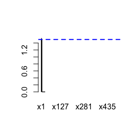

```r
barplot(coef_mean)
abline(h=(minB+maxB)/2,lwd=2,lty=2,col="blue")
```

```r
head(coef_lasso_mean, 40)
```

```
#>           x1           x2           x3           x4           x5           x6
#> 3.006611e-01 2.896028e-01 2.358448e-01 2.374641e-01 3.065951e-01 1.633413e-03
#>           x7           x8           x9          x10          x11          x12
#> 8.285933e-03 2.664676e-03 1.286248e-03 2.328200e-03 8.799246e-04 8.072028e-03
#>          x13          x14          x15          x16          x17          x18
#> 7.044725e-03 6.158855e-03 2.491027e-03 0.000000e+00 6.908800e-04 1.025494e-03
#>          x19          x20          x21          x22          x23          x24
#> 5.153866e-04 1.810606e-04 2.887157e-03 1.164730e-02 3.420346e-03 0.000000e+00
#>          x25          x26          x27          x28          x29          x30
#> 0.000000e+00 1.058844e-02 6.975349e-03 0.000000e+00 0.000000e+00 0.000000e+00
#>          x31          x32          x33          x34          x35          x36
#> 2.711486e-03 3.698186e-03 3.852792e-05 3.575717e-03 0.000000e+00 1.036557e-02
#>          x37          x38          x39          x40
#> 1.824428e-03 7.742724e-03 1.557148e-03 8.436719e-03
```

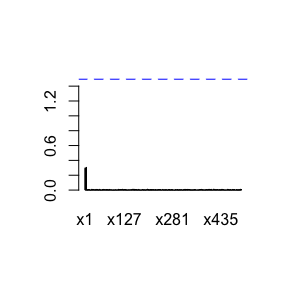

```r
barplot(coef_lasso_mean,ylim=c(0,1.5))
abline(h=(minB+maxB)/2,lwd=2,lty=2,col="blue")
```

The simulation process looks sucessfull: the lasso estimates retrives mostly the correct variables, yet the other ones are also selected sometimes. What are the confidence indices for those variables?